# Setting up Databricks for PySpark

[figure not shown]

# 1 How to Register

- If you have never used Databricks before, proceed to step 1.
- If you have used Databricks before and have an account, proceed to step 6.
1. Go to [Databricks](https://www.databricks.com/) and scroll to where it says “Ready to become a data + AI company?” and click *Try it free*

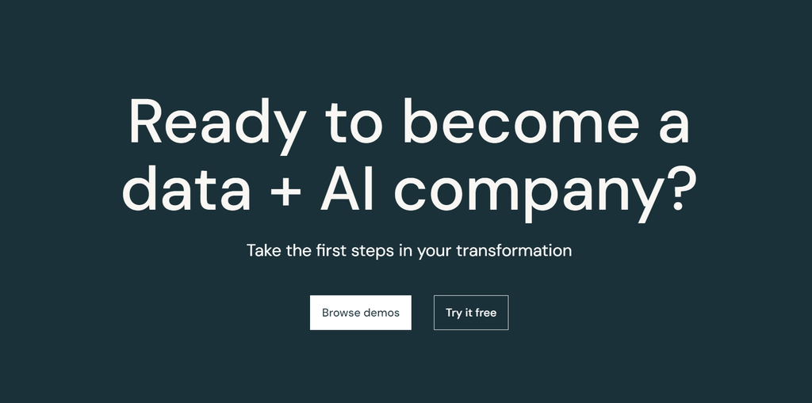

2. Input the required details and click “Continue”.

[figure not shown]

3. Choose “Get started with Community Edition” at the bottom of the next menu.

[figure not shown]

4. A verification email will be sent to you to validate your email address.

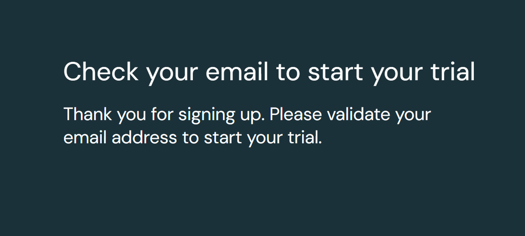

Click the link within and create a password.

[figure not shown]

5. After completing step 4, you should be logged into Databricks. Step 7 shows the homepage you should see.
6. You can login at the following [Databricks URL](https://community.cloud.databricks.com/login.html).

[figure not shown]

7. You should see the following home page with the Data Science and Engineering features listed with links.

[figure not shown]

In particular, you can:

- Import and transform data.
- Create a new notebook for analysis and machine learning
- Automatically apply machine learning to a dataset.

The sidebar on the left has shortcuts to all of these features, and we recommend using the New (with plus sign) to begin the next sections.

# 2 Creating a cluster

1. Press the plus on the left hand menu, or the “Create” button and select “Cluster”. You will learn more about clusters in the course materials.

[figure not shown]

2. On the “New Compute” page, give your cluster a name and keep the runtime version as the default.

Click “Create compute” and wait for a while whilst the cluster is spun up.

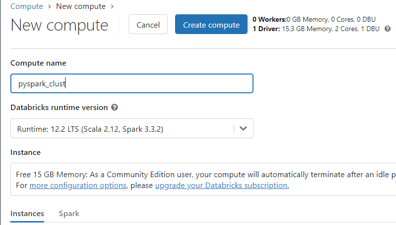

When this is completed, it will look like this.

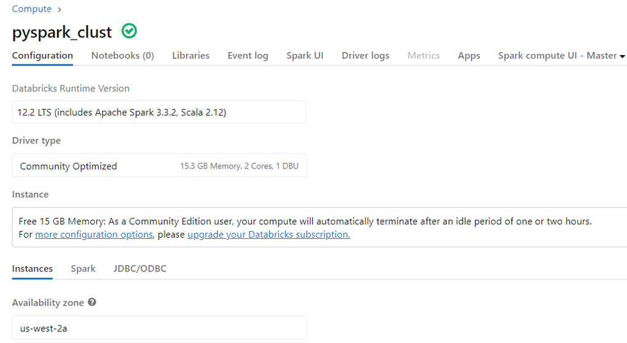

# 3 Import Datasets and Create Tables

**Important: You will need to complete the following steps multiple times, once for each required dataset!**

To be able to read datasets in using sparks read in functions, you must upload the data to its FileStore.

1. Click on the create (plus sign) button again and select “Table”. This will take you to the create new table tool.

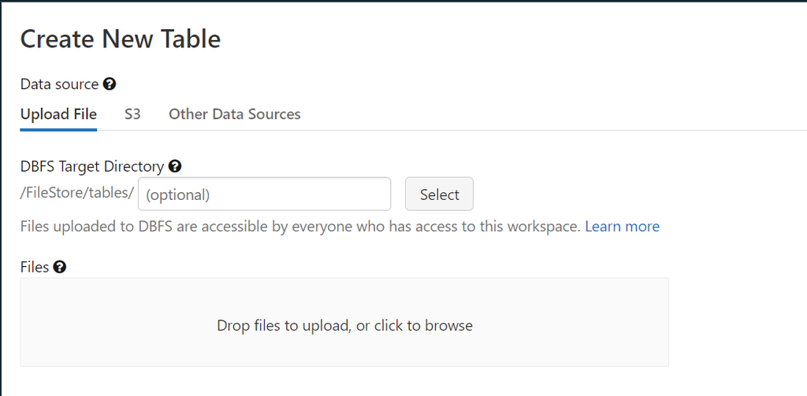

2. Either:
- Click on the “Files” box to open up a file explorer browser. Navigate to the course materials “data” folder and upload the csv file.
- Drag and drop the dataset into the “Files” box.

Once it is uploaded, a note will appear below that the file was uploaded to “/FileStore/tables/.” which will be the filepath used to read the data in later.

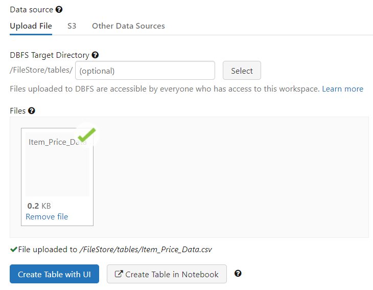

3. Now that the data is uploaded, SQL tables can be created using the “Create Table with UI” button.

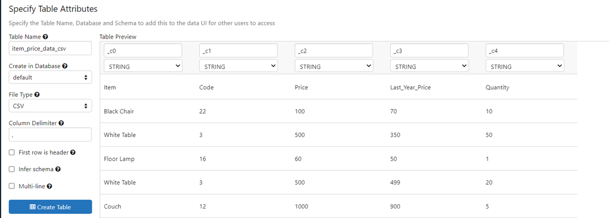

There are numerous options available for how the table should be stored.

- You should change the table name - usually, “_csv” is attached to the dataset name.
- You should tick “First row is header”, as this is not always the case by default.
- You should manually check the type of each column with the dropdowns beneath them, or allow spark to do this by ticking “Infer schema”.

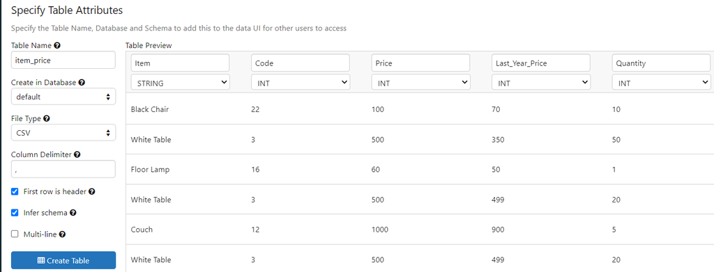

Finally, click “Create Table”. The final dataset and its schema are shown for you to review.

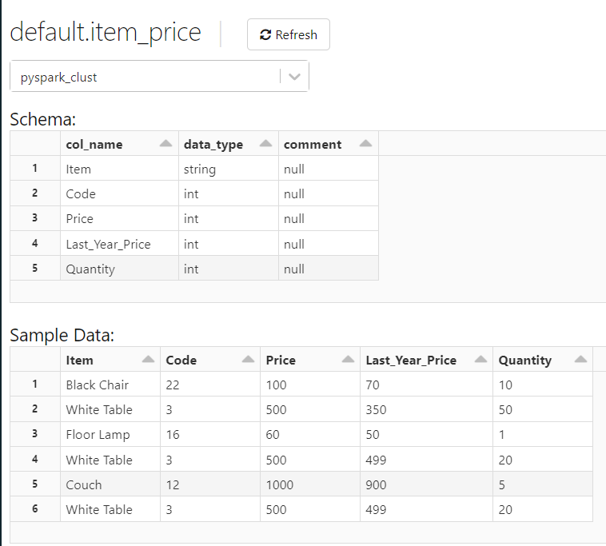

4. To check the dataset, select “Catalog” in the left hand menu.

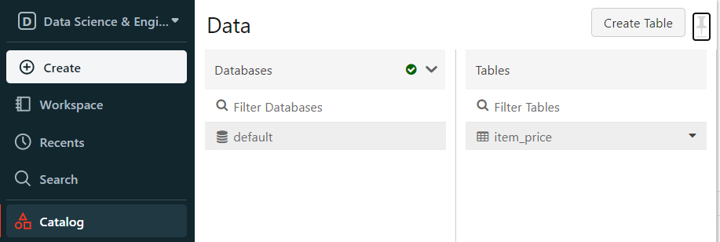

# 4 Create a Coding Notebook

With a cluster created and tables loaded in, you can proceed to open a coding notebook for the course materials.

Notebooks are similar to other interfaces like Jupyter and RMarkdown, where:

- Code
- Explanatory Text
- Plots
- Equations

and more can be combined.

1. Click the create (plus sign) button again and select “Notebook”.

[figure not shown]

2. Notice that:
- The cluster is attached and could be changed if we wish.
- It is untitled with date and time.
- The code cell and drop down next to its name say “Python” by default.

Clicking the name will allow you to change it’s name and you can even change the associated programming language with the drop down next to it should you wish.

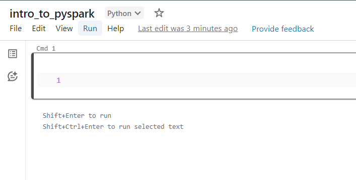

3. On the right hand side there is the symbol **{x}** which is the **variable explorer**.

[figure not shown]

4. Let’s run a single code cell to get started. Type the following:
- greeting = “Hello World!”

and run with SHIFT + ENTER, which also inputs a new code cell beneath.

> **Note**: CTRL + ENTER will work as well, but won’t input new cells, so you will need to hover over the bottom of the cell frame and click plus.

You can now proceed to the Intro to PySpark HTML.